# R Notebook

SeaWatch Group Project

Target Variable: GROSS - We would like to predict the Gross donations for a given area.

```r
mydata <- na.omit(Seawatch_C_w_blanks[, 3:20])
str(mydata)
```

```
Classes ‘tbl_df’, ‘tbl’ and 'data.frame':   359 obs. of  18 variables:
 $ GROSS  : num  6222 8641 10687 2423 2609 ...
 $ CNVHRS : num  238 294 351 160 134 81 39 187 201 297 ...
 $ MOY    : num  9 9 9 7 7 7 3 7 7 7 ...
 $ YR     : num  80 81 82 81 82 83 83 81 82 83 ...
 $ MON    : num  9 21 33 19 31 43 39 19 31 43 ...
 $ VISIT  : num  1 2 3 1 2 3 1 1 2 3 ...
 $ LST    : num  0 0 1 0 0 1 1 0 0 1 ...
 $ CPI    : num  249 276 293 271 291 ...
 $ POP80  : num  17544 17544 17544 10381 10381 ...
 $ HHMEDI : num  27323 27323 27323 19387 19387 ...
 $ PERCAPI: num  10522 10522 10522 7317 7317 ...
 $ POVPR  : num  3.8 3.8 3.8 6.3 6.3 6.3 10.1 25.4 25.4 25.4 ...
 $ MFGPR  : num  35.6 35.6 35.6 27.8 27.8 27.8 40.6 4.6 4.6 4.6 ...
 $ COLLPR : num  47.3 47.3 47.3 15.2 15.2 15.2 13.3 56.5 56.5 56.5 ...
 $ MAGE   : num  29.7 29.7 29.7 32.1 32.1 32.1 29.5 21.7 21.7 21.7 ...
 $ CART   : num  2663 2663 2663 4215 4215 ...
 $ REAG   : num  3667 3667 3667 4758 4758 ...
 $ ANDR   : num  2047 2047 2047 1685 1685 ...
 - attr(*, "na.action")= 'omit' Named int  30 31 32 33 40 41 42 43 44 45 ...
  ..- attr(*, "names")= chr  "30" "31" "32" "33" ...
```

```r
for (col in 2:ncol(mydata)){
  hist(unlist(mydata[,col]),main = names(df[col]))
}
```

[output not shown]

```
Error in df[col] : object of type 'closure' is not subsettable
```

Note: There’s a town where the median age is 21.7, where the PERCAPI is only $5,000 and where 56% has college degrees. This is probably a college town.

MFGPR- Percentage with manufacturing jobs. We should also multiply this by POP80 CART - # votes for Carter, here we see a strong multiplicative relationship? ANDR- # votes for ANDR, here we see a strong multiplicative relationship? REAG- # votes for Reagan, multiplicative relationship?

Here, we wanted to investigate what the extreme values of POP80 were.

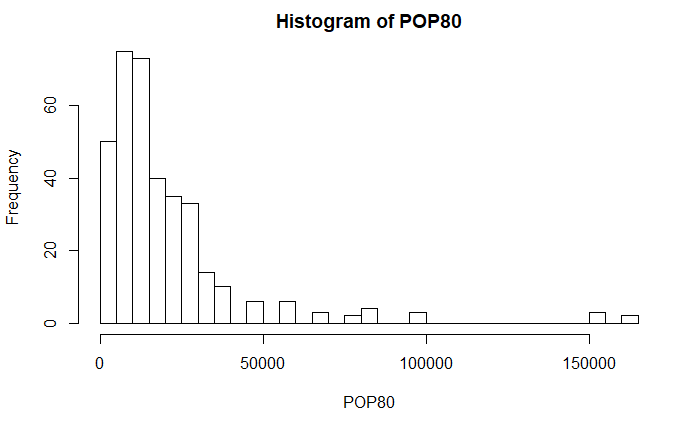

```r
hist(POP80,nclass=30)
```

```r
mydata[mydata$POP80==max(mydata$POP80,na.rm=T),]
```

|  | GROSS | CNVHRS | MOY | YR | MON | VISIT | LST | CPI | POP80 | HHMEDI | PERCAPI | POVPR | MFGPR | COLLPR | MAGE | CART | REAG | ANDR |
| --- | --- | --- | --- | --- | --- | --- | --- | --- | --- | --- | --- | --- | --- | --- | --- | --- | --- | --- |
| 394 | 4962 | 230 | 7 | 82 | 31 | 1 | 0 | 290.6 | 161799 | 14116 | 6443 | 14.4 | 27.2 | 14.8 | 31 | 31225 | 23339 | 8586 |
| 395 | 2065 | 94 | 7 | 83 | 43 | 2 | 1 | 299.6 | 161799 | 14116 | 6443 | 14.4 | 27.2 | 14.8 | 31 | 31225 | 23339 | 8586 |

Here we see that the extreme has a population of 161,799 people and that both rows are coming from the same town on two different visits. This population is not that extreme. It is probably Boston. We could easily figure this out, but it doesn’t look to be a problem.

As we understood the variables, we noticed that HHMEDI and PERCAPI tell us similar information and thus could potentially be highly correlated, so we took at look at this correlation.

```r
cor(HHMEDI, PERCAPI, use = "complete.obs")
```

```
[1] 0.8976733
```

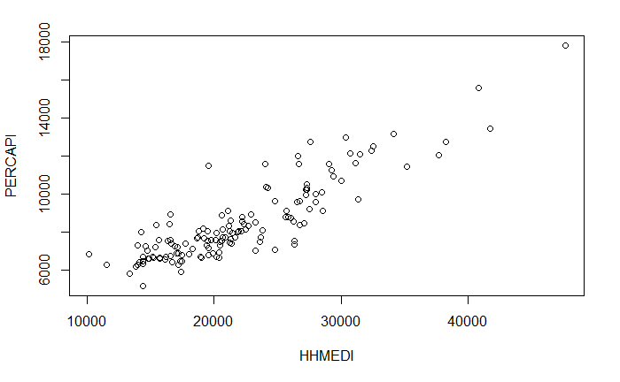

```r
plot(HHMEDI, PERCAPI)
```

So here we see that there is a very strong linear relationship between these two variables. In our model, we should choose to incorporate only one of these. If we incorporated both, we would end up double counting this attribute due to the high multicolinearity.

Next, we took a look at the variable POVPR which represents the percent of the population under the poverty line as a number (not a percentage). Because we saw some flaring out in the scatter chart, it is a good idea to see if we can transform this variable. Here we wanted to turn it into the number of people under the poverty line in each city.

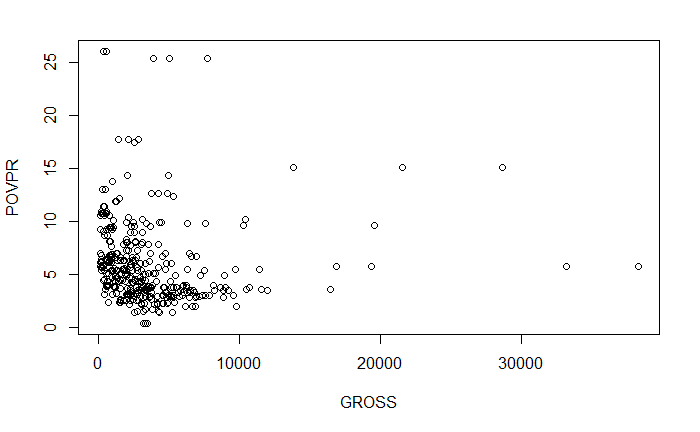

```r
plot(GROSS, POVPR)
```

```r
mydata$povnum <- mydata$POVPR/100 * mydata$POP80
attach(mydata)
cor(GROSS, povnum)
```

```
[1] 0.2392347
```

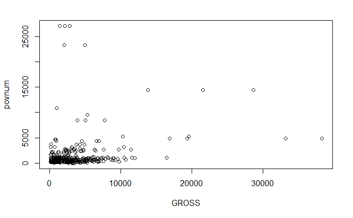

```r
plot(GROSS, povnum)
```

This attribute is clearly not perfect still, but is better. You see that the correlation increased from 0.05 to 0.24

WE can try a similar process for MFGPR

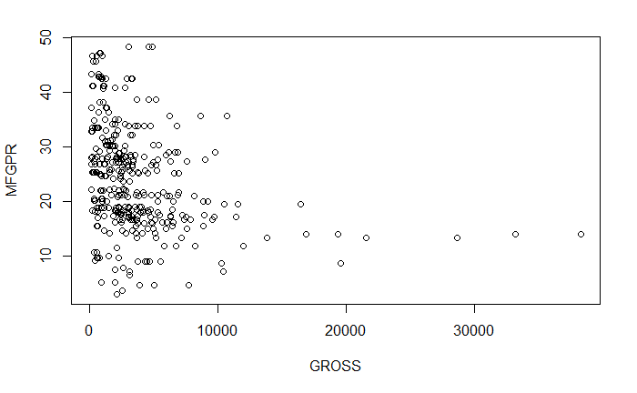

```r
plot(GROSS,MFGPR)
```

```r
cor(GROSS,MFGPR,use = "complete.obs")
```

```
[1] -0.3003965
```

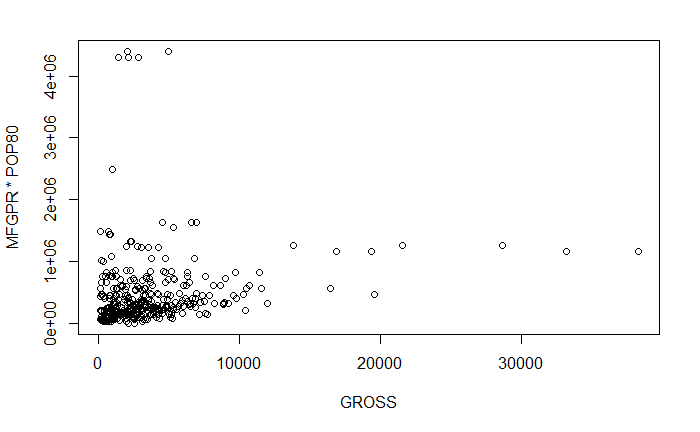

```r
plot(GROSS,MFGPR*POP80)
```

```r
cor(GROSS,MFGPR*POP80,use="complete.obs")
```

```
[1] 0.1739273
```

Here we see multiplying by POP80 actually decreased the correlation, so maybe we should just use MFGPR rather than transforming it.

Another thing variable we can look at more would be MAGE

When we do so, we see that there’s a few observations where the MAGE is really low. We can take a look to try to understand what’s going on here.

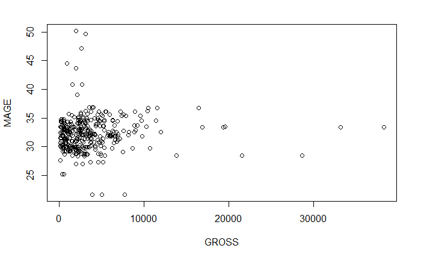

```r
plot(GROSS,MAGE)
```

```r
cor(GROSS,MAGE,use="complete.obs")
```

```
[1] 0.05750895
```

```r
mydata[mydata$MAGE==min(mydata$MAGE,na.rm=T),]
```

|  | GROSS | CNVHRS | MOY | YR | MON | VISIT | LST | CPI | POP80 | HHMEDI | PERCAPI | POVPR | MFGPR | COLLPR | MAGE | CART | REAG | ANDR | povnum |
| --- | --- | --- | --- | --- | --- | --- | --- | --- | --- | --- | --- | --- | --- | --- | --- | --- | --- | --- | --- |
| 8 | 3881 | 187 | 7 | 81 | 19 | 1 | 0 | 271.3 | 33229 | 14349 | 5188 | 25.4 | 4.6 | 56.5 | 21.7 | 6001 | 2421 | 2850 | 8440.166 |
| 9 | 5037 | 201 | 7 | 82 | 31 | 2 | 0 | 290.6 | 33229 | 14349 | 5188 | 25.4 | 4.6 | 56.5 | 21.7 | 6001 | 2421 | 2850 | 8440.166 |
| 10 | 7716 | 297 | 7 | 83 | 43 | 3 | 1 | 299.6 | 33229 | 14349 | 5188 | 25.4 | 4.6 | 56.5 | 21.7 | 6001 | 2421 | 2850 | 8440.166 |

By looking at the other attributes in these observations it becomes clear that the observations all come from the same town and that that town is more likely a college town. We also see that, while the MAGE being around 30-35 could come with a wide variety of GROSS donations, older towns really only stay in the less than ~5000 range. This is probably just due to a lack of observations in this town, but it could be something to look at as a cluster – towns with high MAGEs.

Next, we look at the president attributes

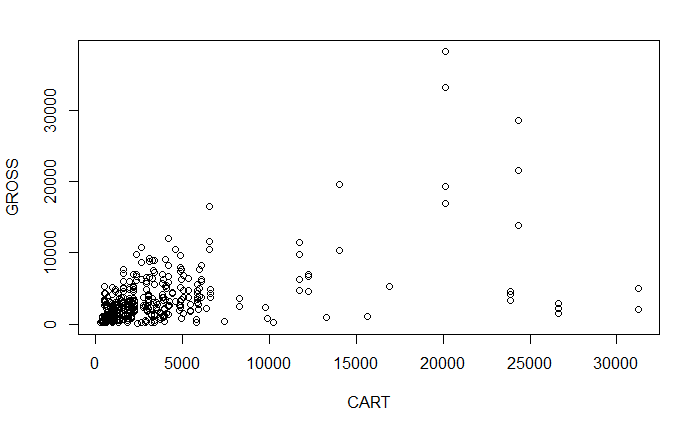

```r
plot(CART,GROSS)
```

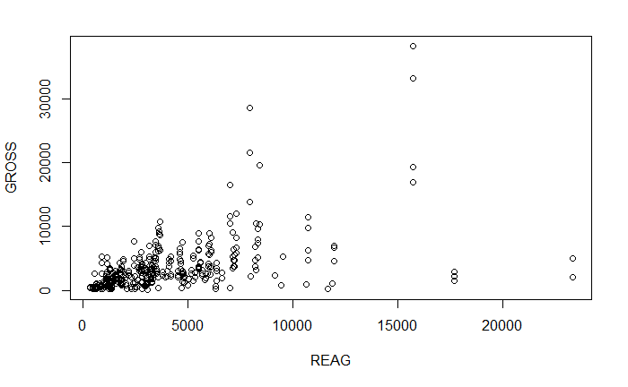

```r
plot(REAG,GROSS)
```

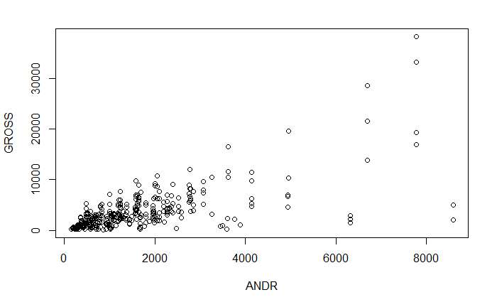

```r
plot(ANDR,GROSS)
```

```r
cor(GROSS,CART,use="complete.obs")
```

```
[1] 0.4872417
```

```r
cor(GROSS,REAG,use="complete.obs")
```

```
[1] 0.4949702
```

```r
cor(GROSS,ANDR,use="complete.obs")
```

```
[1] 0.6716217
```

Here we see a couple things. 1) All three attributes look like they have strong correlations with GROSS from the plots, although we also really do see the flaring out that indicates a multiplicative effect. 2) We also see that there’s a high correlation between the three attributes. Due to this multicolinearity, we would most likely want to only use one in our model.

One thing we can try with the flaring out would be to turn the number of votes to a percentage of the town.

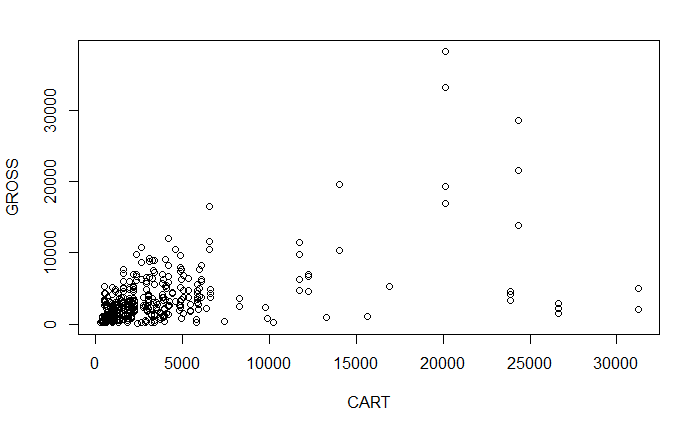

```r
plot(CART,GROSS)
```

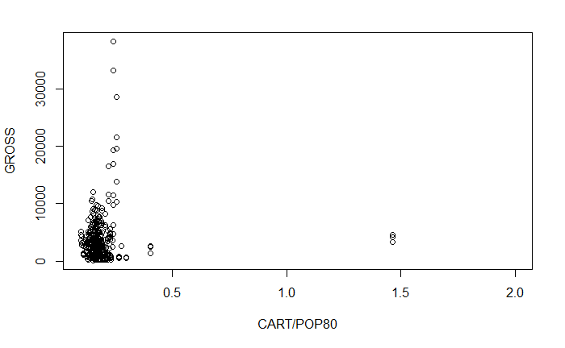

```r
plot(CART/POP80,GROSS,xlim = c(0.1,2))
```

```r
cor(GROSS, CART)
```

```
[1] 0.4872417
```

```r
cor(GROSS, CART/POP80)
```

```
[1] 0.06197288
```

Here we see that the correlation decreases significantly when you divide by POP80, so maybe that’s not the best thing to do. We also see, however, that there are some points where the percentage of people in the town voting for CART is 1.4. This doesn’t make any sense and thus indicates that these points are incorrect. We may want to eliminate them. But even in towns where the percentage is less than 1, we may want to further investigate where total votes in 1980 are greater than the population.

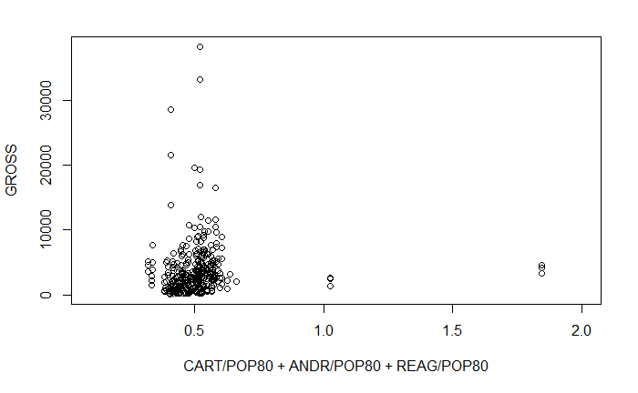

```r
plot(CART/POP80+ANDR/POP80+REAG/POP80,GROSS,xlim = c(0.1,2))
```

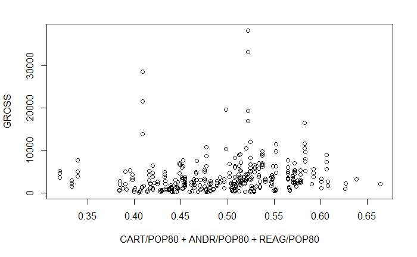

```r
mydata <- (mydata[POP80>CART + ANDR + REAG,])
attach(mydata)
plot(CART/POP80+ANDR/POP80+REAG/POP80,GROSS)
```

We can also transform COLLPR to get numcoll

```r
describe(mydata)
```

|  | vars | n | mean | sd | median | trimmed | mad | min | max | range | skew | kurtosis | se |
| --- | --- | --- | --- | --- | --- | --- | --- | --- | --- | --- | --- | --- | --- |
| GROSS | 1 | 353 | 3555.48 | 4190.13 | 2542.00 | 2833.22 | 2336.58 | 117.0 | 38256.00 | 38139.00 | 4.08 | 24.21 | 223.02 |
| CNVHRS | 2 | 353 | 147.79 | 144.90 | 117.00 | 124.82 | 97.85 | 8.0 | 1204.00 | 1196.00 | 3.10 | 14.91 | 7.71 |
| MOY | 3 | 353 | 6.66 | 2.45 | 7.00 | 6.69 | 1.48 | 1.0 | 12.00 | 11.00 | -0.17 | 0.52 | 0.13 |
| YR | 4 | 353 | 81.78 | 1.00 | 82.00 | 81.84 | 1.48 | 80.0 | 83.00 | 3.00 | -0.27 | -1.04 | 0.05 |
| MON | 5 | 353 | 27.97 | 11.74 | 31.00 | 28.65 | 17.79 | 4.0 | 44.00 | 40.00 | -0.26 | -1.08 | 0.62 |
| VISIT | 6 | 353 | 1.99 | 0.95 | 2.00 | 1.89 | 1.48 | 1.0 | 5.00 | 4.00 | 0.66 | -0.28 | 0.05 |
| LST | 7 | 353 | 0.41 | 0.49 | 0.00 | 0.39 | 0.00 | 0.0 | 1.00 | 1.00 | 0.37 | -1.87 | 0.03 |
| CPI | 8 | 353 | 281.91 | 16.91 | 290.60 | 284.02 | 13.34 | 239.8 | 300.90 | 61.10 | -0.82 | -0.47 | 0.90 |
| POP80 | 9 | 353 | 20103.62 | 23202.25 | 13601.00 | 15525.17 | 11484.22 | 2002.0 | 161799.00 | 159797.00 | 3.55 | 15.97 | 1234.93 |
| HHMEDI | 10 | 353 | 22919.44 | 6714.64 | 21816.00 | 22282.52 | 6981.56 | 10108.0 | 47646.00 | 37538.00 | 1.00 | 1.38 | 357.38 |

[output cut: 10 more lines]

```r
mydata$num_COLL<-COLLPR*POP80
cor(GROSS, num_COLL)
```

```
[1] 0.8133781
```

```r
attach(mydata)
```

Now, let’s try making our first model

```r
model1<-lm(GROSS~POP80+MOY+CPI+num_COLL+PERCAPI)
describe(GROSS)
```

|  | vars | n | mean | sd | median | trimmed | mad | min | max | range | skew | kurtosis | se |
| --- | --- | --- | --- | --- | --- | --- | --- | --- | --- | --- | --- | --- | --- |
| X1 | 1 | 353 | 3555.48 | 4190.13 | 2542 | 2833.22 | 2336.58 | 117 | 38256 | 38139 | 4.08 | 24.21 | 223.02 |

```r
summary(model1)
```

```
Call:
lm(formula = GROSS ~ POP80 + MOY + CPI + num_COLL + PERCAPI)

Residuals:
    Min      1Q  Median      3Q     Max
-8003.9  -826.1  -127.2   759.3 14510.0

Coefficients:
              Estimate Std. Error t value Pr(>|t|)
(Intercept) -1.323e+04  1.979e+03  -6.684 9.28e-11 ***
POP80       -6.898e-02  7.841e-03  -8.797  < 2e-16 ***
MOY          6.753e+01  4.263e+01   1.584    0.114
CPI          3.960e+01  6.305e+00   6.281 1.01e-09 ***
num_COLL     6.989e-03  2.778e-04  25.156  < 2e-16 ***
PERCAPI      3.083e-01  5.373e-02   5.737 2.10e-08 ***
---
Signif. codes:  0 ‘***’ 0.001 ‘**’ 0.01 ‘*’ 0.05 ‘.’ 0.1 ‘ ’ 1

Residual standard error: 1926 on 347 degrees of freedom
Multiple R-squared:  0.7917,    Adjusted R-squared:  0.7887
F-statistic: 263.8 on 5 and 347 DF,  p-value: < 2.2e-16
```

```r
cor(mydata)
```

```
                GROSS       CNVHRS          MOY           YR          MON        VISIT          LST          CPI        POP80      HHMEDI     PERCAPI       POVPR
GROSS     1.000000000  0.970525079 -0.019443999  0.001836654 -0.002184737  0.476176932  0.022869377 -0.017908350  0.438556392  0.24068559  0.38972071 -0.04835709
CNVHRS    0.970525079  1.000000000  0.008796166 -0.099760814 -0.099765159  0.402687809 -0.040730891 -0.116942687  0.489309335  0.22910374  0.38243131 -0.05458587
MOY      -0.019443999  0.008796166  1.000000000 -0.189974300  0.015084212 -0.065167542 -0.046311326  0.053753805 -0.061605568 -0.14727860 -0.15049100  0.02404609
YR        0.001836654 -0.099760814 -0.189974300  1.000000000  0.978811750  0.573425799  0.685072404  0.947142460 -0.083469674 -0.17529317 -0.18675211  0.16223208
MON      -0.002184737 -0.099765159  0.015084212  0.978811750  1.000000000  0.570404306  0.688041533  0.975811896 -0.097856732 -0.20924079 -0.22158092  0.17023754
VISIT     0.476176932  0.402687809 -0.065167542  0.573425799  0.570404306  1.000000000  0.483655908  0.541343568  0.070752540  0.26726120  0.32147188 -0.13115583
LST       0.022869377 -0.040730891 -0.046311326  0.685072404  0.688041533  0.483655908  1.000000000  0.582071880  0.006833657 -0.12905434 -0.11450639  0.08114249
CPI      -0.017908350 -0.116942687  0.053753805  0.947142460  0.975811896  0.541343568  0.582071880  1.000000000 -0.105284140 -0.21407496 -0.23604068  0.17100934
POP80     0.438556392  0.489309335 -0.061605568 -0.083469674 -0.097856732  0.070752540  0.006833657 -0.105284140  1.000000000 -0.21617598 -0.10780925  0.35141945
HHMEDI    0.240685594  0.229103740 -0.147278598 -0.175293171 -0.209240788  0.267261197 -0.129054341 -0.214074963 -0.216175979  1.00000000  0.89559044 -0.69713038
PERCAPI   0.389720714  0.382431305 -0.150491003 -0.186752106 -0.221580924  0.321471882 -0.114506386 -0.236040679 -0.107809253  0.89559044  1.00000000 -0.56050703
POVPR    -0.048357094 -0.054585869  0.024046094  0.162232081  0.170237539 -0.131155833  0.081142494  0.171009343  0.351419452 -0.69713038 -0.56050703  1.00000000
MFGPR    -0.299587941 -0.326657332  0.012762170  0.043820270  0.047289684 -0.103290914 -0.023579519  0.075673437 -0.069981517 -0.11287314 -0.28491694 -0.13016357
COLLPR    0.489891369  0.468648354 -0.103087892 -0.147362546 -0.171578896  0.326458886 -0.126128356 -0.181183062 -0.072912535  0.76419189  0.84679453 -0.28736140
MAGE      0.056836676  0.069253656  0.050180521  0.024986678  0.035912917  0.006737035  0.069976735  0.008718632 -0.122775810  0.10796191  0.32405170 -0.23325730
CART      0.518734887  0.560242548 -0.069869959 -0.077925636 -0.093934125  0.094974896  0.005732259 -0.102292710  0.979722625 -0.22848423 -0.09107271  0.35547373
REAG      0.495905830  0.581239220 -0.031498805 -0.159800594 -0.169315573  0.102785978 -0.001696149 -0.184925197  0.920317146 -0.06330099  0.04333857  0.12998148
ANDR      0.672294992  0.731365376 -0.040120833 -0.156012746 -0.167256116  0.175542437 -0.019539556 -0.183267461  0.921040685 -0.08203397  0.07720713  0.22605700
povnum    0.239138503  0.257745795 -0.061455920  0.017955251  0.005468954  0.007826150  0.018947090  0.003895744  0.910147693 -0.32033013 -0.22528971  0.54500190
num_COLL  0.813378107  0.843520106 -0.059871126 -0.136579925 -0.151584220  0.264824267 -0.059364959 -0.163910291  0.776434147  0.03929278  0.20533925  0.20124571
               MFGPR       COLLPR         MAGE         CART         REAG        ANDR       povnum    num_COLL
GROSS    -0.29958794  0.489891369  0.056836676  0.518734887  0.495905830  0.67229499  0.239138503  0.81337811
CNVHRS   -0.32665733  0.468648354  0.069253656  0.560242548  0.581239220  0.73136538  0.257745795  0.84352011
MOY       0.01276217 -0.103087892  0.050180521 -0.069869959 -0.031498805 -0.04012083 -0.061455920 -0.05987113
YR        0.04382027 -0.147362546  0.024986678 -0.077925636 -0.159800594 -0.15601275  0.017955251 -0.13657993
MON       0.04728968 -0.171578896  0.035912917 -0.093934125 -0.169315573 -0.16725612  0.005468954 -0.15158422
VISIT    -0.10329091  0.326458886  0.006737035  0.094974896  0.102785978  0.17554244  0.007826150  0.26482427
LST      -0.02357952 -0.126128356  0.069976735  0.005732259 -0.001696149 -0.01953956  0.018947090 -0.05936496
CPI       0.07567344 -0.181183062  0.008718632 -0.102292710 -0.184925197 -0.18326746  0.003895744 -0.16391029
POP80    -0.06998152 -0.072912535 -0.122775810  0.979722625  0.920317146  0.92104068  0.910147693  0.77643415
HHMEDI   -0.11287314  0.764191890  0.107961906 -0.228484226 -0.063300993 -0.08203397 -0.320330132  0.03929278
PERCAPI  -0.28491694  0.846794533  0.324051698 -0.091072711  0.043338574  0.07720713 -0.225289708  0.20533925
POVPR    -0.13016357 -0.287361403 -0.233257300  0.355473731  0.129981476  0.22605700  0.545001897  0.20124571
MFGPR     1.00000000 -0.439071349 -0.327193865 -0.105744299 -0.132325707 -0.21604673 -0.054307845 -0.28859164
COLLPR   -0.43907135  1.000000000  0.113161671 -0.045703875 -0.004343913  0.12933509 -0.117298971  0.35294609
MAGE     -0.32719386  0.113161671  1.000000000 -0.090559678  0.027780255 -0.01590076 -0.180287456 -0.07166685
CART     -0.10574430 -0.045703875 -0.090559678  1.000000000  0.892187713  0.93889477  0.873969305  0.83632418
REAG     -0.13232571 -0.004343913  0.027780255  0.892187713  1.000000000  0.93698990  0.705926440  0.75597112
ANDR     -0.21604673  0.129335090 -0.015900758  0.938894766  0.936989898  1.00000000  0.728168927  0.91471187
povnum   -0.05430784 -0.117298971 -0.180287456  0.873969305  0.705926440  0.72816893  1.000000000  0.60639467
num_COLL -0.28859164  0.352946088 -0.071666846  0.836324183  0.755971125  0.91471187  0.606394674  1.00000000
```

Here visit, has a very high correlation, but right now we can’t use it because we need to transform it into a factor

```r
mydata$VISIT<-as.factor(mydata$VISIT)
```

And now let’s create another model.

```r
model2<- lm(GROSS ~ VISIT + POP80 + PERCAPI + MFGPR + REAG + povnum + num_COLL)
summary(model2)
```

```
Call:
lm(formula = GROSS ~ VISIT + POP80 + PERCAPI + MFGPR + REAG +
    povnum + num_COLL)

Residuals:
    Min      1Q  Median      3Q     Max
-6418.3  -828.7    29.1   725.1 13475.1

Coefficients:
              Estimate Std. Error t value Pr(>|t|)
(Intercept) -1.743e+03  5.790e+02  -3.010  0.00281 **
VISIT        9.208e+02  1.124e+02   8.191 5.11e-15 ***
POP80       -4.443e-02  4.358e-02  -1.020  0.30860
PERCAPI      9.005e-02  5.468e-02   1.647  0.10051
MFGPR        2.445e+00  1.225e+01   0.200  0.84191
REAG         9.746e-02  1.499e-01   0.650  0.51614
povnum      -2.261e-01  1.463e-01  -1.546  0.12300
num_COLL     6.284e-03  3.413e-04  18.413  < 2e-16 ***
---
Signif. codes:  0 ‘***’ 0.001 ‘**’ 0.01 ‘*’ 0.05 ‘.’ 0.1 ‘ ’ 1

Residual standard error: 1837 on 345 degrees of freedom
Multiple R-squared:  0.8117,    Adjusted R-squared:  0.8079
F-statistic: 212.4 on 7 and 345 DF,  p-value: < 2.2e-16
```

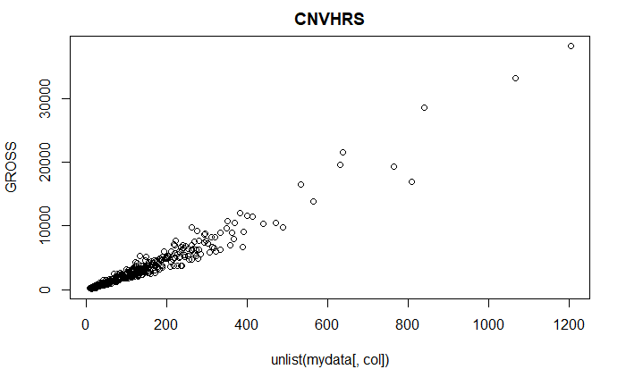

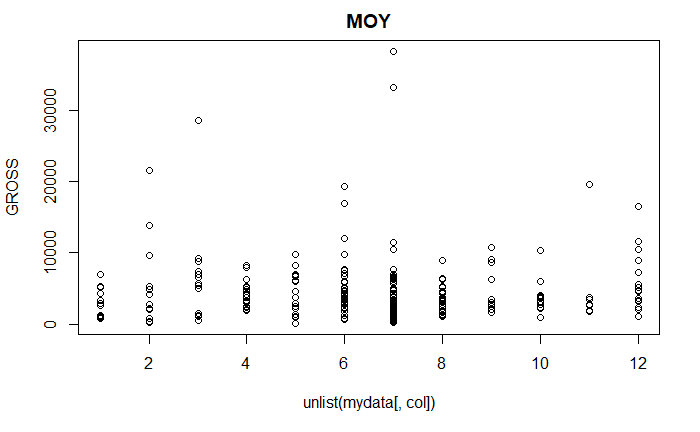

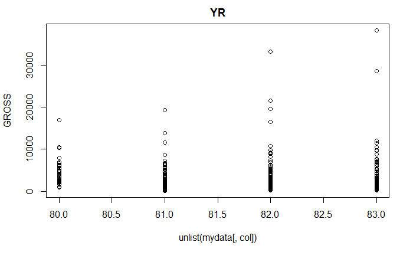

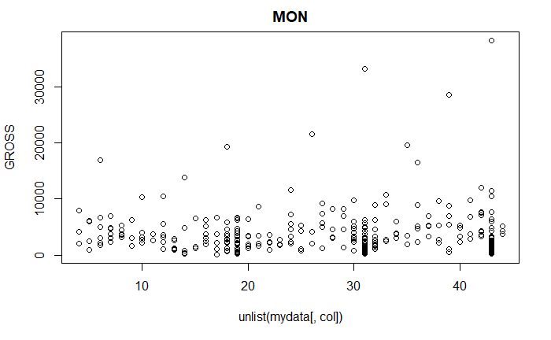

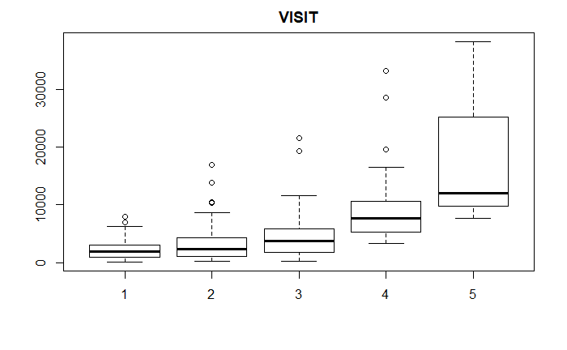

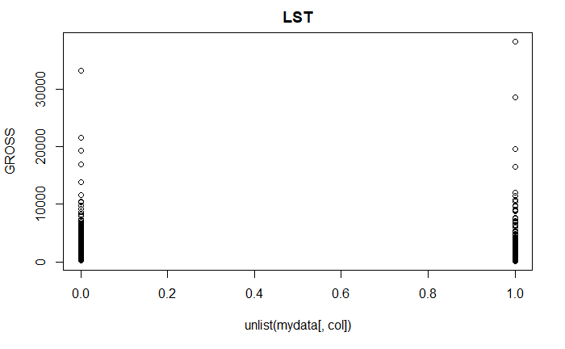

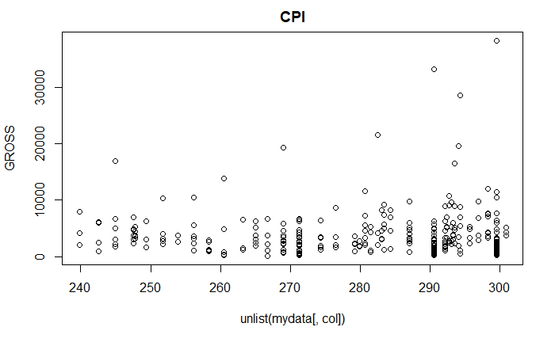

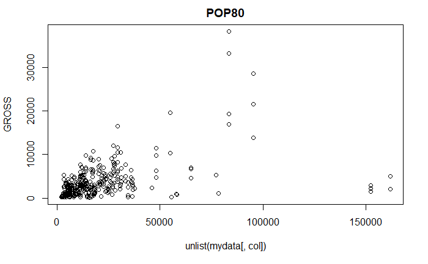

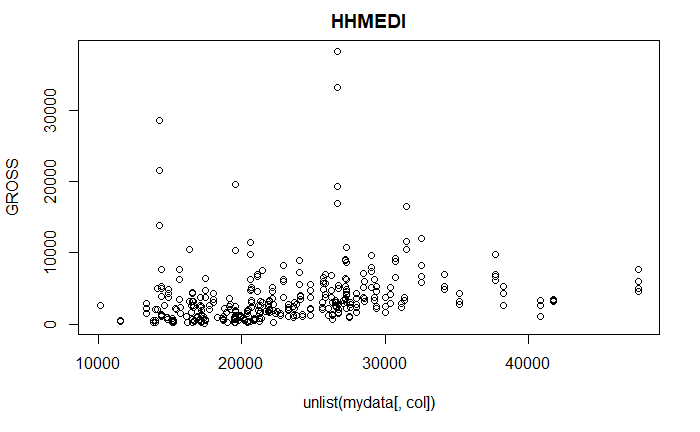

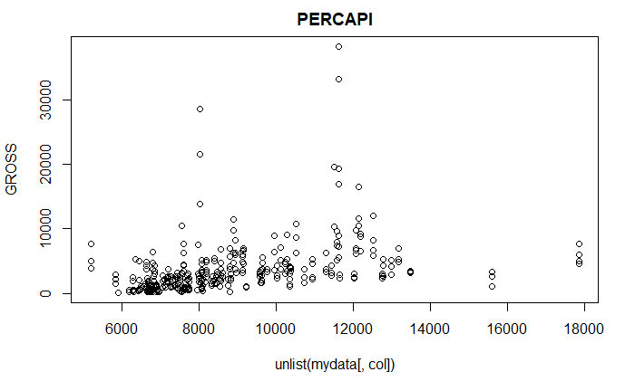

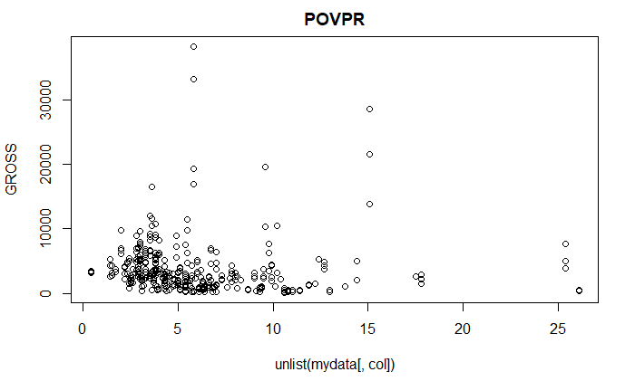

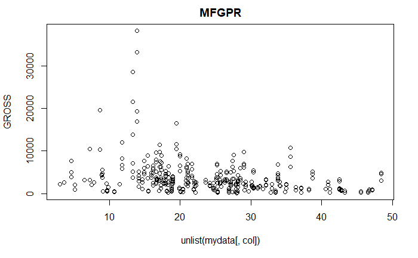

[7 more figures not shown]

```r
attach(mydata)
for (col in 2:ncol(mydata)){
  plot(unlist(mydata[,col]), GROSS, main = names(mydata[col]))
}
```